# FTAP Stats Pset1

Zachary Fogelson

July 12, 2015

### Problem 1

- lemma 1: If the mean of a dataset X is $\mu_0$ then the mean of a dataset f(X), where f is a linear function, is $f(\mu_0)$

$\mu_0 = \frac{\Sigma_{i=1}^{N}x_i}{N} = \frac{x_1 + x_2 + \ldots + x_N}{N}$ $f(x) = b + mx$ $f(X) = f(x_1), f(x_2), \ldots, f(x_N)$ $\mu_1 = \frac{\Sigma_{i=1}^{N}f(x_i)}{N} = \frac{b + mx_1 + b + mx_2 + \ldots + b + mx_N}{N}$ $\mu_1 = \frac{N \dot b}{N} + m \frac{ (x_1 + x_2 + \ldots +, x_N)}{N} = b + m\mu_0$

- lemma 2: If the standard deviation of a dataset X is $\sigma_0$ then the standard deviation of a dataset f(X), where $f(x) = c_0 + c_1x$, is $\sigma_1 = c_1 \sigma_0$ $\sigma_x^2 = \frac{\Sigma_{i=1}^N (x_i - \mu_x)}{N}$ Based on lemma 1, we know that the mean of f(X) is f($\mu_x$) $\sigma_x^2 = \frac{((f(x_1)-f(\mu_x))^2 + \ldots + (f(x_N) - f(\mu_x))^2}{N}$ At any given step of the summation $f(x_i)-f(\mu_x) = c_0 + c1x_i - (c0 +c1\mu_x) = c1(x_i - \mu_x)$ $\sigma_x^2 = \frac{(c_1(x_i - \mu_x))^2 + \ldots + (c1(x_i - \mu_x))^2}{N} = \frac{c1^2(x_i - \mu_x)^2 + \ldots + c1^2(x_i - \mu_x)^2}{N}$ $\sigma_x^2 = c_1^2\frac{(x_i - \mu_x)^2 + \ldots + (x_i - \mu_x)^2}{N} = c_1^2 \sigma_0^2$ $\sigma_x = c_1 \sigma_0$

#### a. Show that $cov((c_0 + c_1 \cdot x), (d_0 + d_1 \cdot y)) = c_1 \cdot d_1 cov(x,y)$

$cov(x,y) = \frac{\Sigma_{i=1}^{N}(x_i - \mu_x)(y_i - \mu_y)}{N}$ $cov(f(x), g(y)) = \frac{\Sigma_{i=1}^{N}(f(x_i) - f(\mu_x))(g(y_i) - g(\mu_y))}{N} =$

$\frac{(c_0 + c_1x_1 - (c_0 + c_1\mu_x))(d_0 + d_1y_1 - (d_0 + d_1\mu_y)) + \ldots + (c_0 + c_1x_N - (c_0 + c_1\mu_x))(d_0 + d_1y_N - (d_0 + d_1\mu_y))}{N}$

$\frac{(c_1x_1 - c_1\mu_x)(d_1y_1 - d_1\mu_y) + \ldots + (c_1x_N - c_1\mu_x)(d_1y_N - d_1\mu_y)}{N}$ $cov(f(x), g(y)) = \frac{c_1d1(x_1 - \mu_x)(y_1 - \mu_y) + \ldots + c_1d_1(x_N-\mu_x)(y_N-\mu_y)}{N} = c_1 d_1 \frac{\Sigma_{i=1}^N(x_i - \mu_x)(y_i - \mu_y)}{N} = c_1d_1 cov(x,y)$

#### b. Show that $corr((c_0 + c_1 \cdot x), (d_0 + d_1 \cdot y)) = corr(x,y)$

$corr(x,y) = \frac{cov(x,y)}{\sigma_x\sigma_y}$ From part a we know that $cov(f(x), g(y)) = c_1d_1 cov(x,y)$ and from lemma 2 we know that $sigma_1 = \sigma_x = c_1 \sigma_0$ when a linear function f is applied to a data set X therefore, $corr(f(x),g(y)) = \frac{c_1d_1 cov(x,y)}{c_1d_1\sigma_x\sigma_y} = corr(x,y)$

### Problem 2

#### a.

```r
library(xts)
```

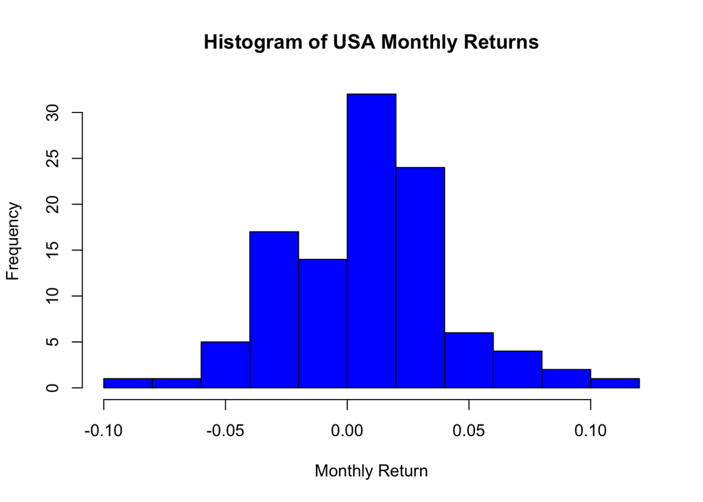

```r
setwd("/Users/zachfogelson/Developer/FTAP Stats HW")
# Assuming that conret is in current working directory
conret <- read.csv("conret.csv", header = TRUE)

titles <- "Histogram of %s Monthly Returns"
xlabel <- "Monthly Return"

# USA
hist(conret$usa,
     main   = sprintf(sprintf(titles, "USA")),
     xlab   = xlabel,
     border ="black",
     col    = "blue",
     breaks = 10)
```

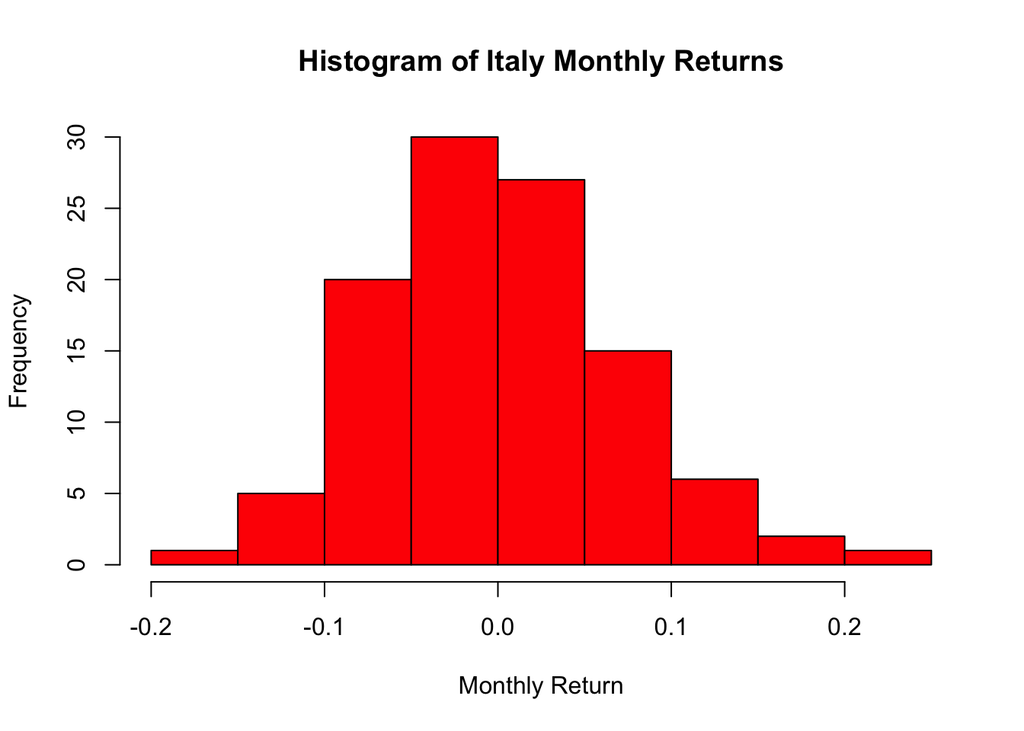

```r
# Italy
hist(conret$italy,
     main   = sprintf(titles, "Italy"),
     xlab   = xlabel,
     border = "black",
     col    = "red",
     breaks = 10)
```

#### b.

Based on these results, Italy’s returns appear more spread out because its monthly returns have a larger range–(-.2,.2)–than those of the USA– (-.1 to .1).

#### c.

```r
# USA
print(mean(conret$usa))  # 0.01345794
```

```
## [1] 0.01345794
```

```r
print(sd(conret$usa))  # 0.03328275
```

```
## [1] 0.03328275
```

```r
# Italy
print(mean(conret$italy))  # 0.006074766
```

```
## [1] 0.006074766
```

```r
print(sd(conret$italy))  # 0.07126561
```

```
## [1] 0.07126561
```

Because the standard deviation of Italy’s monthly returns is larger than the standard deviation of the United States’ monthly returns this supports the conclusion that Italy’s monthly returns are more spread out than those of the United States.

#### d.

According to the empirical rule 95% of all data should be within 2 standard deviations of the mean.

```r
getRange <- function(m, s){
  list(low <- m - 2 * s, high <- m + 2 * s)
}

percentageResultsInRange <- function(arr, r){
    acceptable <- arr[arr > r[1] & arr < r[2]]
    length(acceptable) / length(arr)
}

usaRange <- getRange(mean(conret$usa), sd(conret$usa))
italyRange <- getRange(mean(conret$italy), sd(conret$italy))

print(percentageResultsInRange(conret$usa, usaRange))  # 0.953271
```

```
## [1] 0.953271
```

```r
print(percentageResultsInRange(conret$italy, italyRange))  # 0.9439252
```

```
## [1] 0.9439252
```

Yes each of the intervals are approximately correct, the USA has slightly more data within two standard deviations while the Italian data has slightly less.

#### e.

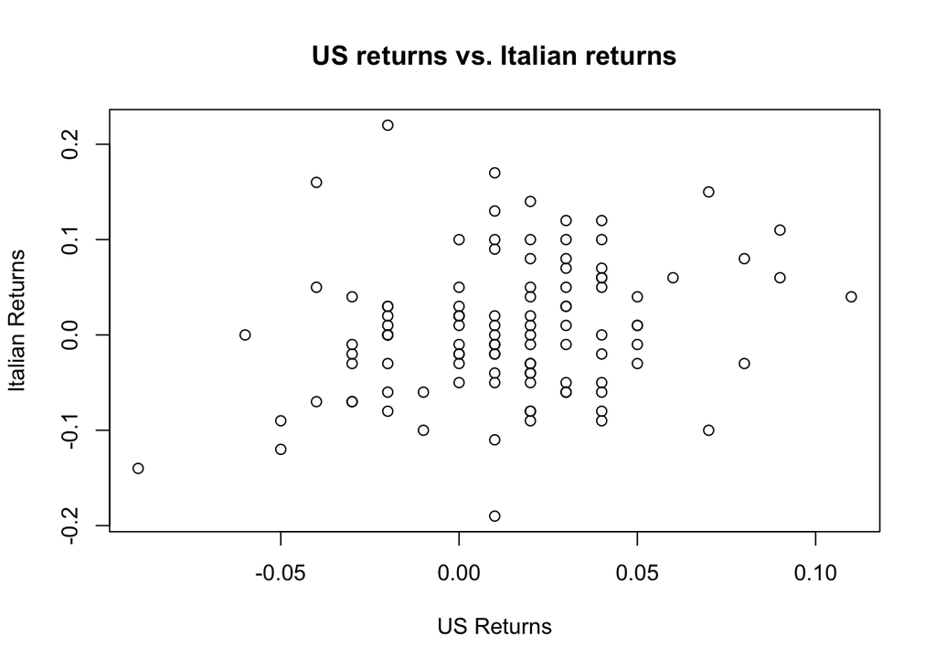

```r
plot(conret$usa,
     conret$italy,
     main = "US returns vs. Italian returns",
     xlab = "US Returns",
     ylab = "Italian Returns")
```

Based on the scatter plot, I expect the correlation between US and Italian returns is approximately .6

#### f

```r
print(cov(conret$usa, conret$italy, use = "all.obs"))  # 0.0005693617
```

```
## [1] 0.0005693617
```

```r
print(cor(conret$usa, conret$italy, use = "all.obs"))  # 0.240043
```

```
## [1] 0.240043
```

My guess compared to the actual correlation was far too high

### Problem 3

#### a

Assuming that oil_gdp.csv is in current working directory

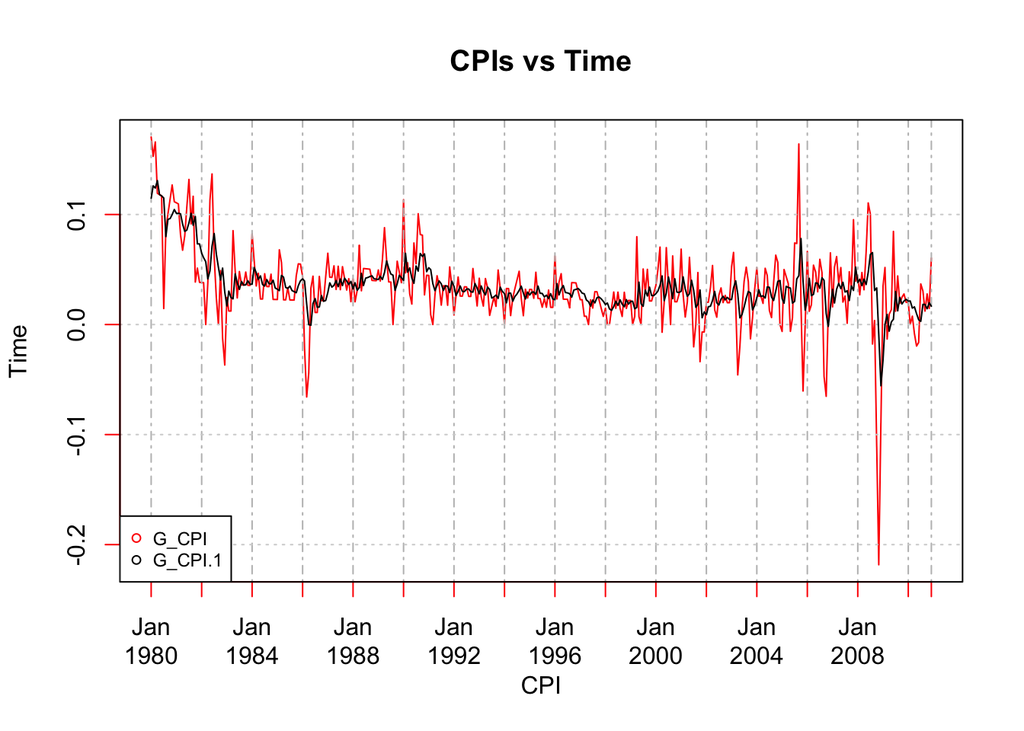

```r
oil_gdp <- read.csv("oil_gdp.csv", header = TRUE)
cpiOverTime1 = xts(x=oil_gdp$G_CPI, order.by=as.Date(oil_gdp$OBS, "%m/%d/%y"))
cpiOverTime2 = xts(x=oil_gdp$G_CPI.1, order.by=as.Date(oil_gdp$OBS, "%m/%d/%y"))

plot(as.xts(cpiOverTime1), col="red", xlab = "CPI", ylab = "Time", main = "CPIs vs Time", minor.ticks = F)
lines(as.xts(cpiOverTime2))
legend('bottomleft', c("G_CPI","G_CPI.1"), pch=1, col=c('red', 'black'), bty='o', cex=.75)
```

The G_CPI is more volatile then than the G_CPI.1 series

#### b

```r
print(mean(oil_gdp$G_CPI))  # 0.03394408
```

```
## [1] 0.03394408
```

```r
print(var(oil_gdp$G_CPI))  # 0.001356836
```

```
## [1] 0.001356836
```

```r
print(mean(oil_gdp$G_CPI.1))  # 0.03505742
```

```
## [1] 0.03505742
```

```r
print(var(oil_gdp$G_CPI.1))  # 0.0004995316
```

```
## [1] 0.0004995316
```

#### c

Comparing the plots, when G_CPI is high, G_CPI.1 is also high but less so. This is most apparent in the early 1980s but there are also times when G_CPI collapses and G_CPI.1 appears to track it such as circa 1986 as well as circa 2009.

#### d

```r
print(cov(oil_gdp$G_CPI, oil_gdp$G_CPI.1, use = "all.obs"))  # 0.0004749797
```

```
## [1] 0.0004749797
```

```r
print(cor(oil_gdp$G_CPI, oil_gdp$G_CPI.1, use = "all.obs"))  # 0.5769391
```

```
## [1] 0.5769391
```

# f

```r
print(cor(oil_gdp$G_CPI.1[seq(length=length(oil_gdp$G_CPI)-1, from=2)],
    oil_gdp$G_CPI[seq(length=length(oil_gdp$G_CPI)-1, from=1)]))  # 0.8505302
```

```
## [1] 0.8505302
```

### Problem 4

#### a

```r
conret$usaItaly <- .5 * conret$usa + .5 * conret$italy
print(mean(conret$usaItaly))  # 0.009766355
```

```
## [1] 0.009766355
```

```r
print(sd(conret$usaItaly))  # 0.04279384
```

```
## [1] 0.04279384
```

#### b

```r
linComboMean <- function(w1, m1, w2, m2){
  w1*m1 + w2*m2
}
linComboVar <- function(w1, sd1, w2, sd2, cr){
  w1^2 * sd1^2 + w2^2 * sd2^2 + 2 * w1 * w2 * cr * sd1 * sd2
}

print(linComboMean(.5, mean(conret$usa), .5, mean(conret$italy)))  # 0.009766355
```

```
## [1] 0.009766355
```

```r
print(linComboVar(.5, sd(conret$usa),
                  .5, sd(conret$italy),
                  cor(conret$usa, conret$italy, use = "all.obs"))^(1/2))  # 0.04279384
```

```
## [1] 0.04279384
```

#### c

```r
# .25 USA, .75 Italy
print(linComboMean(.25, mean(conret$usa), .75, mean(conret$italy)))  # 0.007920561
```

```
## [1] 0.007920561
```

```r
print(linComboVar(.25, sd(conret$usa),
                  .75, sd(conret$italy),
                  cor(conret$usa, conret$italy, use = "all.obs"))^(1/2))  # 0.05603179
```

```
## [1] 0.05603179
```

```r
# .75 USA, .25 Italy
print(linComboMean(.75, mean(conret$usa), .25, mean(conret$italy)))  # 0.01161215
```

```
## [1] 0.01161215
```

```r
print(linComboVar(.75, sd(conret$usa),
                  .25, sd(conret$italy),
                  cor(conret$usa, conret$italy, use = "all.obs"))^(1/2))  # 0.03397115
```

```
## [1] 0.03397115
```

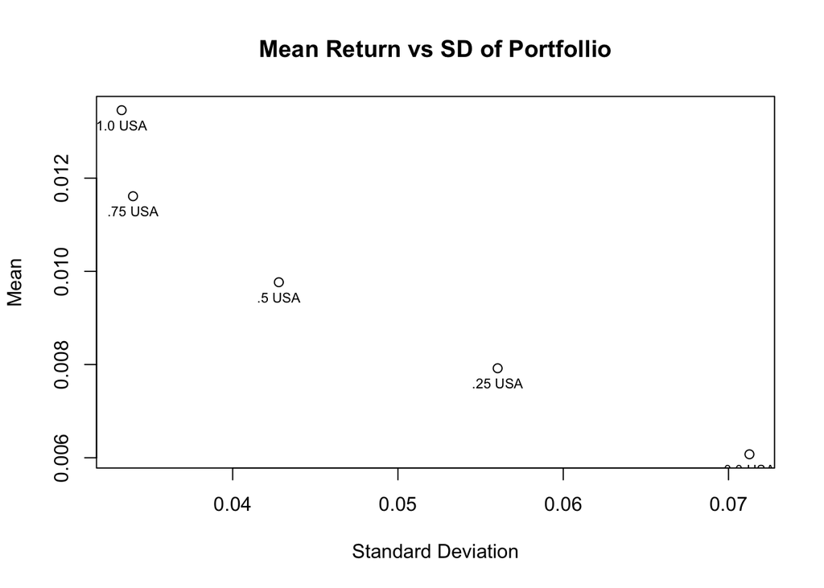

```r
investRatio <- list(0, .25, .5, .75, 1)
investMean <- list()
investSD <- list()

for (el in investRatio){
  investMean <- c(investMean, linComboMean(el, mean(conret$usa), 1 - el, mean(conret$italy)))
  investSD <- c(investSD, linComboVar(el, sd(conret$usa),
                          1-el, sd(conret$italy),
                          cor(conret$usa, conret$italy, use = "all.obs"))^(1/2))
}

plot(investSD,
     investMean,
     main = "Mean Return vs SD of Portfollio",
     xlab = "Standard Deviation",
     ylab = "Mean")
text(x = investSD, y = investMean, labels = c("0.0 USA", ".25 USA", ".5 USA", ".75 USA", "1.0 USA"), cex = .7, pos = 1)
```

#### Problem 5

| meaning | value | probability |
| --- | --- | --- |
| Fails | 1 | .2 |
| Meets | 2 | .5 |
| Exceeds | 3 | .3 |
| Total |  | 1 |

##### a.

Yes, this is a valid rando variable because the sum of the proabilities of all the possible outcomes adds to 1

##### b.

$P(X = 2 \cup X = 3) = 1 - P(X = 1) = .8$

#### Problem 6

| X/Y | Neagtive = 0 | Positive = 1 | Total |
| --- | --- | --- | --- |
| Below = 1 | .15 | .05 | .2 |
| Meets = 2 | .2 | .3 | .5 |
| Exceeds = 3 | .1 | .2 | .3 |
| Total | .45 | .55 | 1 |

##### a

$P(X = 2 \cap Y = 1) = .3$

##### b

$P(Y = 1) = .55$

##### c

$P(X = 2) = .5$

#### Problem 7

| $X_{i+1}$/$X_i$ | Recession = 0 | Expansion = 1 | Total |
| --- | --- | --- | --- |
| Recession = 0 | .2 | .15 | .35 |
| Expansion = 1 | .15 | .5 | .65 |
| Total | .35 | .65 | 1 |

##### a

$P(x_i = 1 \cap x_{i+1} = 1) \stackrel{?}{\ne} P(x_i = 1) P(x_{i+1} = 1)$ $.5 \stackrel{?}{\ne} .65^2$ $.5 \ne .4225$

Therefore, these events are not statistically independent.

##### b

Yes, $X_i$ and $X_{i+1}$ are identically distributed.

##### c

$P(X_{i+1} = 0) = .35$

##### d

$P(X_{i+1} = 0 | X_i = 0) = \frac{.2}{.35} = .5714$ $P(X_{i+1} = 1 | X_i = 0) = \frac{.15}{.35} = .4286$

##### e

$P(X_{i+1} = 1 | X_i = 1) = \frac{.5}{.65} = .7692$ $P(X_{i+1} = 1 | X_i = 1) = \frac{.15}{.65} = .2307$

##### f

This model suggests that if we are in a recession this year we are more likely to be in a recession next year as compared to going from not being in an expansion this year an then going into a recession next year. However, The probability of being in a recession this year and transitioning into a recovery next year is still relatively high. If there is an expansion this year, it is highly likely that the expansion will continue into next year as compared to going into a recession next year.

#### Problem 8

$X = $ Manager’s Performance $X = 1$ implies Manager beat the market $X = 0$ implies the market outperformed the manager $P(X=1) = .65$

Assume that manager’s performance year-to-year is independent.

##### a

.65

##### b

.65

##### c

$.65^6 = .075$

##### d

$(1-.65)^6 = .00184$

##### e

| Number of times beating the market | Formal | Probability |
| --- | --- | --- |
| 0 | ${6 \choose 0} (.35)^6$ | .001838 |
| 1 | ${6 \choose 1} (.35)^5(.65)$ | .0205 |
| 2 | ${6 \choose 2} (.35)^4(.65)^2$ | .0951 |
| 3 | ${6 \choose 3} (.35)^3(.65)^3$ | .2355 |
| 4 | ${6 \choose 4} (.35)^2(.65)^4$ | .3280 |
| 5 | ${6 \choose 5} (.35)(.65)^5$ | .2437 |
| 6 | ${6 \choose 6} (.65)^6$ | .0754 |